# OUR PROJECT

### Airbnb is a platform that lists private accommodations for rental. It connects people who want to rent out their homes with others who are looking for an accommodation in that location.

### Our Project focuses on an empirical analysis of Airbnb listings in the US in order to determine price drivers. We obtained the dataset for those Airbnb listings from kaggle. There were several steps involved to make the data usable and derive insights from it.

# INITIALISING PACKAGES AND OBTAINING OVERVIEW OF DATA SET

```python
import pandas as pd
import numpy as np
import matplotlib.pyplot as plt
import seaborn as sns
import re
from datetime import datetime
```

```python
airbnb = pd.read_csv('airbnb.csv', delimiter = ',')
```

```python
print(airbnb.shape)
```

```
(74111, 29)
```

```python
print(airbnb.info())
```

```
<class 'pandas.core.frame.DataFrame'>
RangeIndex: 74111 entries, 0 to 74110
Data columns (total 29 columns):
 #   Column                  Non-Null Count  Dtype
---  ------                  --------------  -----
 0   id                      74111 non-null  int64
 1   log_price               74111 non-null  float64
 2   property_type           74111 non-null  object
 3   room_type               74111 non-null  object
 4   amenities               74111 non-null  object
 5   accommodates            74111 non-null  int64
 6   bathrooms               73911 non-null  float64
 7   bed_type                74111 non-null  object
 8   cancellation_policy     74111 non-null  object
 9   cleaning_fee            74111 non-null  bool
```

[output cut: 22 more lines]

```python
print(airbnb.head())
```

```
         id  log_price property_type        room_type  \
0   6901257   5.010635     Apartment  Entire home/apt
1   6304928   5.129899     Apartment  Entire home/apt
2   7919400   4.976734     Apartment  Entire home/apt
3  13418779   6.620073         House  Entire home/apt
4   3808709   4.744932     Apartment  Entire home/apt

                                           amenities  accommodates  bathrooms  \
0  {"Wireless Internet","Air conditioning",Kitche...             3        1.0
1  {"Wireless Internet","Air conditioning",Kitche...             7        1.0
2  {TV,"Cable TV","Wireless Internet","Air condit...             5        1.0
3  {TV,"Cable TV",Internet,"Wireless Internet",Ki...             4        1.0
4  {TV,Internet,"Wireless Internet","Air conditio...             2        1.0

   bed_type cancellation_policy  cleaning_fee  ...   latitude   longitude  \
```

[output cut: 28 more lines]

```python
print(airbnb.columns)
```

```
Index(['id', 'log_price', 'property_type', 'room_type', 'amenities',
       'accommodates', 'bathrooms', 'bed_type', 'cancellation_policy',
       'cleaning_fee', 'city', 'description', 'first_review',
       'host_has_profile_pic', 'host_identity_verified', 'host_response_rate',
       'host_since', 'instant_bookable', 'last_review', 'latitude',
       'longitude', 'name', 'neighbourhood', 'number_of_reviews',
       'review_scores_rating', 'thumbnail_url', 'zipcode', 'bedrooms', 'beds'],
      dtype='object')
```

```python
print(airbnb.describe())
```

```
                 id     log_price  accommodates     bathrooms      latitude  \
count  7.411100e+04  74111.000000  74111.000000  73911.000000  74111.000000
mean   1.126662e+07      4.782069      3.155146      1.235263     38.445958
std    6.081735e+06      0.717394      2.153589      0.582044      3.080167
min    3.440000e+02      0.000000      1.000000      0.000000     33.338905
25%    6.261964e+06      4.317488      2.000000      1.000000     34.127908
50%    1.225415e+07      4.709530      2.000000      1.000000     40.662138
75%    1.640226e+07      5.220356      4.000000      1.000000     40.746096
max    2.123090e+07      7.600402     16.000000      8.000000     42.390437

          longitude  number_of_reviews  review_scores_rating      bedrooms  \
count  74111.000000       74111.000000          57389.000000  74020.000000
mean     -92.397525          20.900568             94.067365      1.265793
std       21.705322          37.828641              7.836556      0.852143
min     -122.511500           0.000000             20.000000      0.000000
25%     -118.342374           1.000000             92.000000      1.000000
50%      -76.996965           6.000000             96.000000      1.000000
75%      -73.954660          23.000000            100.000000      1.000000
max      -70.985047         605.000000            100.000000     10.000000

               beds
count  73980.000000
mean       1.710868
std        1.254142
min        0.000000
25%        1.000000
50%        1.000000
75%        2.000000
max       18.000000
```

```python
print(airbnb.dtypes)
```

```
id                          int64
log_price                 float64
property_type              object
room_type                  object
amenities                  object
accommodates                int64
bathrooms                 float64
bed_type                   object
cancellation_policy        object
cleaning_fee                 bool
city                       object
description                object
first_review               object
host_has_profile_pic       object
host_identity_verified     object
host_response_rate         object
host_since                 object
instant_bookable           object
last_review                object
latitude                  float64
longitude                 float64
name                       object
neighbourhood              object
number_of_reviews           int64
review_scores_rating      float64
thumbnail_url              object
zipcode                    object
bedrooms                  float64
beds                      float64
dtype: object
```

# EVALUATING AND CLEANING THE DATA SET

### Which columns have a high share of missing values? Share of missing values per column:

```python
print(round(airbnb.isnull().sum(axis=0)*100/len(airbnb)))
```

```
id                         0.0
log_price                  0.0
property_type              0.0
room_type                  0.0
amenities                  0.0
accommodates               0.0
bathrooms                  0.0
bed_type                   0.0
cancellation_policy        0.0
cleaning_fee               0.0
city                       0.0
description                0.0
first_review              21.0
host_has_profile_pic       0.0
host_identity_verified     0.0
host_response_rate        25.0
host_since                 0.0
instant_bookable           0.0
last_review               21.0
latitude                   0.0
longitude                  0.0
name                       0.0
neighbourhood              9.0
number_of_reviews          0.0
review_scores_rating      23.0
thumbnail_url             11.0
zipcode                    1.0
bedrooms                   0.0
beds                       0.0
dtype: float64
```

### Eliminating unncessary variables from the data set: large share of missing values, redundant information and unncessary id and url

```python
airbnb = airbnb.drop(['id', 'first_review', 'last_review', 'thumbnail_url', 'zipcode', 'latitude', 'longitude', 'name', 'neighbourhood'], axis=1)
```

### Droping rows from host_response_rate and review_scores_rating that do not contain values:

### Note: we do this because we expect these columns to have an impact on the final price a renter can charge

```python
airbnb = airbnb[airbnb.host_response_rate.isnull() | airbnb.review_scores_rating.isnull() == False]
```

# CREATING NEW USEFUL COLUMNS

### A non-logarithmic version of the price feels more intuitive to us

```python
airbnb['price'] = np.exp(airbnb.log_price)
del airbnb['log_price']
```

### Amenities_count: amount of amenities provided by host

```python
airbnb['amenities'] = airbnb['amenities'].str[1:-1].replace('"', '', regex=True)
p = re.compile(r',translation missing: en.hosting_amenity_50')
airbnb['amenities'] = [p.sub('', x) for x in airbnb['amenities']]
airbnb['amenities_count'] = airbnb['amenities'].str.count(',') + 1
```

### Creating description_len: amount of information provided measured in number of characters (with spaces)

```python
airbnb['description_len'] = airbnb['description'].str.len()
```

### Creating years_host: length of time host has been host (in years)

```python
airbnb['years_host'] = datetime.now().year - airbnb['host_since'].astype(str).apply(lambda x: x.split('-', 1)[0]).astype(int)
```

### Turning host response rate to a float

```python
airbnb['host_response_rate'] = pd.to_numeric(airbnb['host_response_rate'].str[0:-1]).div(100)
```

### Converting columns to boolean: host_has_profile_pic, host_identity_verified, instant_bookable and cleaning_fee

```python
d = {'t':1, 'f':0}
airbnb['host_has_profile_pic'] = airbnb['host_has_profile_pic'].map(d)
airbnb['host_identity_verified'] = airbnb['host_identity_verified'].map(d)
airbnb['instant_bookable'] = airbnb['instant_bookable'].map(d)
```

```python
e = {True:1, False:0}
airbnb['cleaning_fee'] =  pd.to_numeric(airbnb['cleaning_fee'].map(e))
```

```python
airbnb = airbnb.drop(['amenities', 'description', 'host_since'], axis=1)
```

# DATA VISUALISATION

```python
plt.figure(figsize=(15,10))
plt.tight_layout()
sns.set_context('paper',
                font_scale=1.5,
                rc={"lines.linewidth":2.5})
sns.set_style('darkgrid')
```

### Boxplot visualisation of price distribution per city

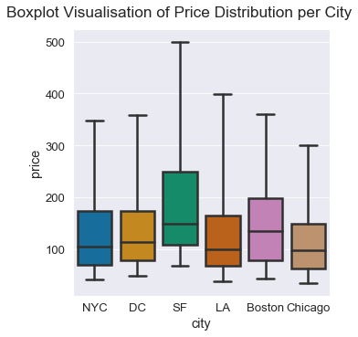

```python
plot1 = sns.catplot(
            'city',
            'price',
            data=airbnb,
            kind='box',
            whis=[5,95],
            palette='colorblind',
            sym='')

plot1.fig.suptitle('Boxplot Visualisation of Price Distribution per City', y=1.03)
plt.show()
```

### Price distribution plot

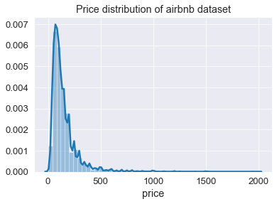

```python
plot5 = sns.distplot(airbnb['price'])
plot5.set_title('Price distribution of airbnb dataset')
plt.show()
```

### Average number of guests accomodated per property type by city

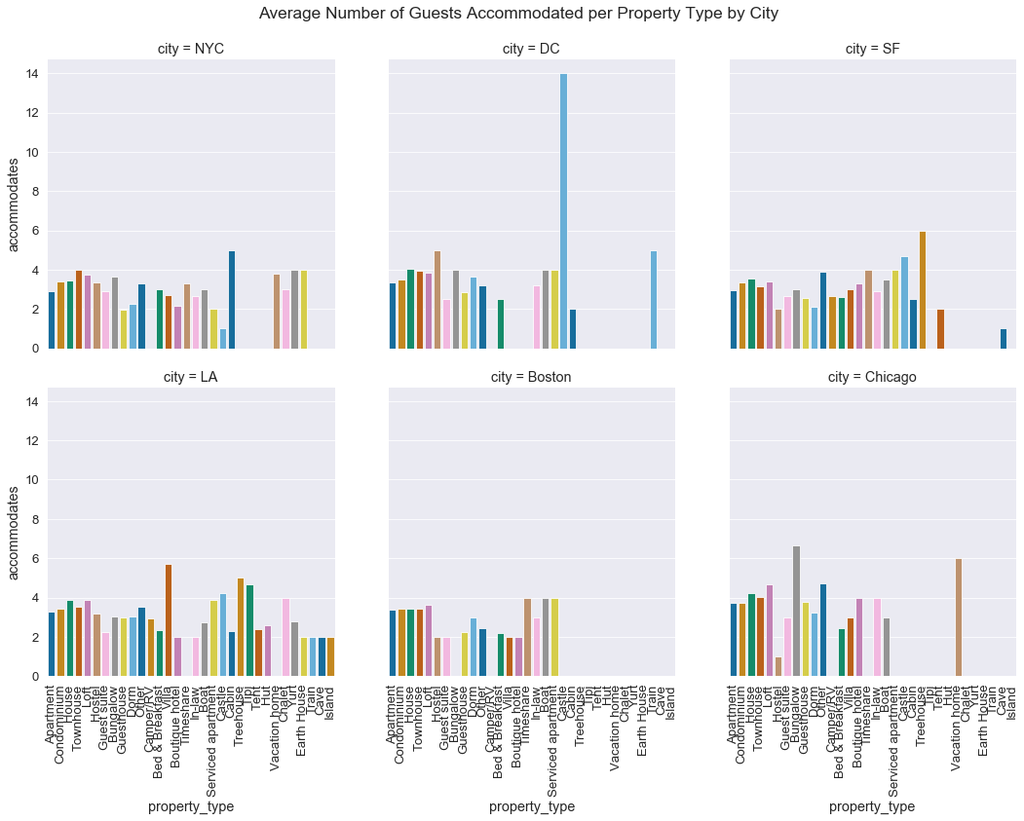

```python
plot2 = sns.catplot(
            'property_type',
            'accommodates',
            data=airbnb,
            kind='bar',
            col='city',
            col_wrap=3,
            ci=None,
            palette='colorblind')

for ax in plot2.axes.ravel():
    ax.set_xticklabels(ax.get_xticklabels(), rotation=90)

plot2.fig.suptitle('Average Number of Guests Accommodated per Property Type by City', y=1.03)
plt.show()
```

```python
plot2.fig.suptitle('Average Number of Guests Accommodated per Property Type by City', y=1.03)
plt.show()
```

### Distribution of the number of guests accomodated per city

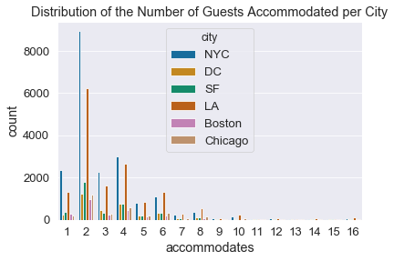

```python
plot3 = sns.countplot(
            airbnb['accommodates'],
            data=airbnb,
            hue='city',
            palette='colorblind')

plot3.set_title('Distribution of the Number of Guests Accommodated per City')
plt.show()
```

### Heatmap of the correlation between the different features of the data set

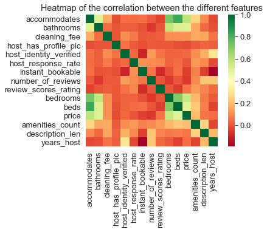

```python
plot4 = sns.heatmap(airbnb.corr(),
                    square=True,
                    cmap='RdYlGn')

plot4.set_title('Heatmap of the correlation between the different features')
plt.show()
```

# CREATING DUMMY VARIABLES AND CLEANING DATA SET (INFINITE & NaN VALUES)

### Obtaining dummy variables to support regression model building

```python
airbnb = pd.get_dummies(airbnb)
```

### Converting infinite values to finite values and eliminating all left-over NaN values

```python
airbnb = airbnb.replace([np.inf, -np.inf], np.nan)
airbnb = airbnb.dropna(axis=0)
```

# REGRESSION ANALYSIS

### Importing necessary packages

```python
from sklearn.linear_model import Ridge, LinearRegression
from sklearn.model_selection import train_test_split, GridSearchCV
from sklearn import metrics
from sklearn.metrics import mean_squared_error, r2_score
```

### Creating training and test data

```python
X = airbnb.drop('price', axis=1).values
y = np.nan_to_num(airbnb['price'].values)
```

```python
X_train, X_test, y_train, y_test = train_test_split(X, y, test_size=0.3, random_state = 42)
```

### Optimising the value of alpha using a Grid Search Method (favoured over Random Search due to large quantity of data)

```python
param_grid = {'alpha': np.array([1,0.1,0.01,0.001,0.0001,0]) }
```

```python
ridge = Ridge(normalize=True)
ridge_cv = GridSearchCV(ridge, param_grid, cv=5)
ridge_cv.fit(X_train, y_train)
```

```
GridSearchCV(cv=5, error_score=nan,
             estimator=Ridge(alpha=1.0, copy_X=True, fit_intercept=True,
                             max_iter=None, normalize=True, random_state=None,
                             solver='auto', tol=0.001),
             iid='deprecated', n_jobs=None,
             param_grid={'alpha': array([1.e+00, 1.e-01, 1.e-02, 1.e-03, 1.e-04, 0.e+00])},
             pre_dispatch='2*n_jobs', refit=True, return_train_score=False,
             scoring=None, verbose=0)
```

```python
print('Best parameters for the ridge regression:', ridge_cv.best_params_)
```

```
Best parameters for the ridge regression: {'alpha': 0.01}
```

```python
print('Best score for the ridge regression:', ridge_cv.best_score_)
```

```
Best score for the ridge regression: 0.5223505293737728
```

### Fitting the model to the training data and predicting it versus y_train

```python
pred_train_ridge_cv= ridge_cv.predict(X_train)
print('Mean Squared Error of the predictions on the training dataset:', np.sqrt(mean_squared_error(y_train,pred_train_ridge_cv)))
print('R-squared of the predictions on the training dataset:', r2_score(y_train, pred_train_ridge_cv))
```

```
Mean Squared Error of the predictions on the training dataset: 93.81558300272798
R-squared of the predictions on the training dataset: 0.5269208756280894
```

### Using the model to predict on X_test, and comparing with y_test

```python
pred_test_ridge_cv = ridge_cv.predict(X_test)
print('Mean Squared Error of the predictions on the test dataset:', np.sqrt(mean_squared_error(y_test,pred_test_ridge_cv)))
print('R-squared of the predictions on the training dataset:', r2_score(y_test, pred_test_ridge_cv))
```

```
Mean Squared Error of the predictions on the test dataset: 97.01219677909583
R-squared of the predictions on the training dataset: 0.503370093987343
```

### Plotting the relative importance of each variable based on coeficients (as a proxy for p-values, which we were not able to calculate)

```python
importance = ridge_cv.best_estimator_.coef_
for i,v in enumerate(importance):
	print('Feature: %0d, Score: %.5f' % (i,v))
```

```
Feature: 0, Score: 13.05117
Feature: 1, Score: 64.33670
Feature: 2, Score: -8.51107
Feature: 3, Score: -58.98584
Feature: 4, Score: 0.72979
Feature: 5, Score: -16.99149
Feature: 6, Score: -7.84234
Feature: 7, Score: -0.12534
Feature: 8, Score: 0.93770
Feature: 9, Score: 34.50174
Feature: 10, Score: -5.73807
Feature: 11, Score: 0.76520
Feature: 12, Score: -0.01071
Feature: 13, Score: 2.35246
Feature: 14, Score: -2.23919
Feature: 15, Score: 3.84182
Feature: 16, Score: 51.59066
Feature: 17, Score: 11.13217
Feature: 18, Score: 0.13720
Feature: 19, Score: -13.59399
Feature: 20, Score: -8.04999
Feature: 21, Score: 72.88357
Feature: 22, Score: 0.00000
Feature: 23, Score: -20.92471
Feature: 24, Score: 12.37512
Feature: 25, Score: -78.69060
Feature: 26, Score: 22.78831
Feature: 27, Score: -27.84263
Feature: 28, Score: -3.47478
Feature: 29, Score: -85.13476
Feature: 30, Score: -2.38767
Feature: 31, Score: -39.04084
Feature: 32, Score: -33.34911
Feature: 33, Score: 91.14509
Feature: 34, Score: 33.63228
Feature: 35, Score: 16.23725
Feature: 36, Score: 95.70331
Feature: 37, Score: 8.50068
Feature: 38, Score: 102.69818
Feature: 39, Score: 35.24135
```

[output cut: 10 more lines]

```
Feature: 50, Score: 13.54385
Feature: 51, Score: -1.71018
Feature: 52, Score: -0.06922
Feature: 53, Score: -2.10553
Feature: 54, Score: -4.24053
Feature: 55, Score: -3.28831
Feature: 56, Score: 4.87186
Feature: 57, Score: 52.79298
Feature: 58, Score: 107.04188
Feature: 59, Score: 8.31343
Feature: 60, Score: -40.67032
Feature: 61, Score: -15.92651
Feature: 62, Score: -14.06099
Feature: 63, Score: 10.39682
Feature: 64, Score: 47.36338
```

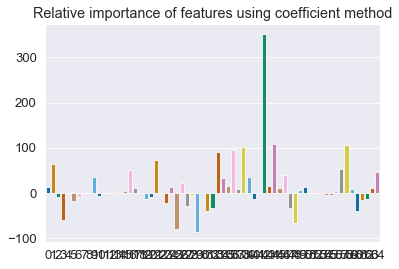

```python
plot6 = sns.barplot([x for x in range(len(importance))],
                     importance,
                     palette='colorblind')

plot6.set_title('Relative importance of features using coefficient method')
plt.show()
```

### Creating training and test data (as dfs)

```python
X = airbnb.drop('price', axis=1)
y = airbnb['price']
```

```python
X_train, X_test, y_train, y_test = train_test_split(X, y, test_size=0.3, random_state=123)
```

### Instantiating the regressor

```python
regressor = LinearRegression()
regressor.fit(X_train, y_train)
```

```
LinearRegression(copy_X=True, fit_intercept=True, n_jobs=None, normalize=False)
```

### Isolating the coefficients

```python
coeff_df = pd.DataFrame(regressor.coef_, X.columns, columns=['Coefficient'])
coeff_df
```

|  | Coefficient |
| --- | --- |
| accommodates | 15.184179 |
| bathrooms | 64.124762 |
| cleaning_fee | -9.173982 |
| host_has_profile_pic | -48.541785 |
| host_identity_verified | 1.528723 |
| ... | ... |
| city_Chicago | -41.684933 |
| city_DC | -12.990804 |
| city_LA | -12.647991 |
| city_NYC | 11.493054 |
| city_SF | 49.984603 |

65 rows × 1 columns

### Predicting Y

```python
y_pred = regressor.predict(X_test)
```

### Comparing y_test vs. y_pred

```python
df = pd.DataFrame({'Actual': y_test, 'Predicted': y_pred})
df1 = df.head(50)
```

### Plotting the comparison

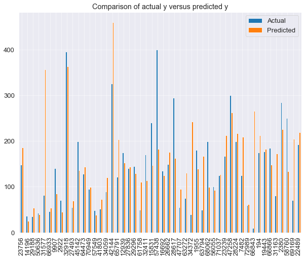

```python
df1.plot(kind='bar',figsize=(10,8))
plt.grid(which='major', linestyle='-', linewidth='0.5', color='white')
plt.grid(which='minor', linestyle=':', linewidth='0.5', color='black')
plt.title('Comparison of actual y versus predicted y')
plt.show()
```

### Values of key indicators

```python
print('Mean Absolute Error:', metrics.mean_absolute_error(y_test, y_pred))
print('Mean Squared Error:', metrics.mean_squared_error(y_test, y_pred))
print('Root Mean Squared Error:', np.sqrt(metrics.mean_squared_error(y_test, y_pred)))
```

```
Mean Absolute Error: 55.437460805928716
Mean Squared Error: 8764.013345655654
Root Mean Squared Error: 93.61630918625052
```

### Determining p-values & significance

### Importing statsmodels.api and applying Ordinary Least Squares method

```python
import statsmodels.api as sm
mod = sm.OLS(y,X)
fii = mod.fit()
```

### Isolating p-values

```python
p_values = fii.summary2().tables[1]['P>|t|']
```

# OUTCOMES

### 1. The Number of statistically signifficant variables impacting the price of an Airbnb listing

```python
print('Statistically significant variables:', (p_values[(p_values < 0.001) == True]).count())
```

```
Statistically significant variables: 34
```

### 2. The most signifficant variables impacting the price of an Airbnb listing (0,001 Level)

```python
print('Statistically significant variables at the 0,001 level:', (p_values[(p_values < 0.001) == True]).sort_values())
```

```
Statistically significant variables at the 0,001 level: bathrooms                               0.000000e+00
bedrooms                                0.000000e+00
accommodates                           1.919069e-260
city_SF                                 2.010744e-77
review_scores_rating                    7.900840e-62
cancellation_policy_flexible            3.681410e-48
cancellation_policy_moderate            1.423868e-47
cancellation_policy_strict              4.963588e-39
room_type_Entire home/apt               2.591788e-38
cancellation_policy_super_strict_60     3.512298e-37
beds                                    1.201424e-33
number_of_reviews                       6.153266e-33
city_Chicago                            1.364167e-25
amenities_count                         1.260391e-24
years_host                              2.137777e-16
property_type_Dorm                      1.333579e-15
property_type_Hostel                    5.395758e-15
property_type_Villa                     6.714871e-15
instant_bookable                        3.473618e-14
cleaning_fee                            6.182855e-12
city_NYC                                3.495456e-11
host_response_rate                      5.301326e-09
property_type_Timeshare                 1.925198e-08
description_len                         2.275210e-08
property_type_Townhouse                 6.133010e-08
room_type_Shared room                   1.202802e-07
property_type_In-law                    5.784902e-06
city_Boston                             9.423641e-06
property_type_Apartment                 3.895634e-05
property_type_House                     4.975059e-05
property_type_Treehouse                 8.185548e-05
host_has_profile_pic                    1.098839e-04
property_type_Guest suite               2.076712e-04
property_type_Guesthouse                4.160622e-04
Name: P>|t|, dtype: float64
```

### 3. The five most signifficant variables impacting the price of an Airbnb listing (0,001 Level)

```python
print('5 most significant variables impacting the price of an Airbnb listing:', (p_values[(p_values < 0.001) == True]).sort_values().head())
```

```
5 most significant variables impacting the price of an Airbnb listing: bathrooms                0.000000e+00
bedrooms                 0.000000e+00
accommodates            1.919069e-260
city_SF                  2.010744e-77
review_scores_rating     7.900840e-62
Name: P>|t|, dtype: float64
```

### Evaluating this outcome, we conclude that the model returns a sensible set of outcomes. Indeed, it stands to reason that the relative size, as characterised by the top 3 variables, would have the most impact on the listing price. Furthermore, San Francisco and its larger metropolitan area is the second most expensive in the United States of America, which is bound to affect the price of a listing (Business Insider, 2019). Finally, the self-explanatory significance of the average rating in a choice of one Airbnb rental over another justifies its impact on the price.

# MODEL LIMITATIONS

### Although the outcome of our work yields some eminently sensible results, we must acknowledge the low r-squared and high RMSE. Clearly, model is lacking certain key criteria that would help it better predict the price.

### When considering why this may be, we conclude that there are more factors that need to be considered. Here, we draw from our personal experiences as travellers and Airbnb users to suggest that the relative location of a listing probably has a major impact on its price. By relative location, we mean being positioned in close proximity to something that enables it to serve a higher purpose than simply that of accommodation. For instance, a flat located near the airport will offer more value to business travellers looking to jet in and out of a city. Interestingly, we found other projects that subsequently validates our assumption (Celekli, 2018).

# RESOURCES USED

### Linear regression: https://towardsdatascience.com/a-beginners-guide-to-linear-regression-in-python-with-scikit-learn-83a8f7ae2b4f

### Kaggle (data source) : https://www.kaggle.com/rudymizrahi/how-i-ranked-5th-160-in-deloitte-s-ml-competition

### Bibliography:

### Business Insider. (2019, May 17). The 15 most expensive cities in America. Retrieved May 22, 2020, from Business Insider: https://www.businessinsider.com/most-expensive-cities-in-america-2019-5?r=US&IR=T

### Celekli, R. (2018). How I ranked 5th/+160 in Deloitte's ML Competition. Retrieved May 22, 2020, from Kaggle: https://www.kaggle.com/rudymizrahi/how-i-ranked-5th-160-in-deloitte-s-ml-competition